# Objective

#### Perform EDA on retail data.

## Download and Prep the Data

#### Import the libraries needed

```python
import pandas as pd
import matplotlib.pyplot as plt
import seaborn as sns
```

#### Load data and store in dataframe

```python
df = pd.read_csv('/content/dataset2.csv',encoding='ISO-8859-1')
df.head()
```

|  | Row ID | Order ID | Order Date | Ship Date | Ship Mode | Customer ID | Customer Name | Segment | City | State | ... | Product ID | Category | Sub-Category | Product Name | Sales | Quantity | Discount | Profit | Shipping Cost | Order Priority |
| --- | --- | --- | --- | --- | --- | --- | --- | --- | --- | --- | --- | --- | --- | --- | --- | --- | --- | --- | --- | --- | --- |
| 0 | 1 | MX-2014-143658 | 10/2/2014 | 10/6/2014 | Standard Class | SC-20575 | Sonia Cooley | Consumer | Mexico City | Distrito Federal | ... | OFF-LA-10002782 | Office Supplies | Labels | Hon File Folder Labels, Adjustable | 13.08 | 3 | 0.0 | 4.56 | 1.03 | Medium |
| 1 | 2 | MX-2012-155047 | 10/15/2012 | 10/20/2012 | Standard Class | KW-16570 | Kelly Williams | Consumer | Dos Quebradas | Risaralda | ... | FUR-FU-10004015 | Furniture | Furnishings | Tenex Clock, Durable | 252.16 | 8 | 0.0 | 90.72 | 13.45 | Medium |
| 2 | 3 | MX-2012-155047 | 10/15/2012 | 10/20/2012 | Standard Class | KW-16570 | Kelly Williams | Consumer | Dos Quebradas | Risaralda | ... | FUR-BO-10002352 | Furniture | Bookcases | Ikea 3-Shelf Cabinet, Mobile | 193.28 | 2 | 0.0 | 54.08 | 9.63 | Medium |
| 3 | 4 | MX-2012-155047 | 10/15/2012 | 10/20/2012 | Standard Class | KW-16570 | Kelly Williams | Consumer | Dos Quebradas | Risaralda | ... | OFF-BI-10004428 | Office Supplies | Binders | Cardinal Binder, Clear | 35.44 | 4 | 0.0 | 4.96 | 1.37 | Medium |
| 4 | 5 | MX-2012-155047 | 10/15/2012 | 10/20/2012 | Standard Class | KW-16570 | Kelly Williams | Consumer | Dos Quebradas | Risaralda | ... | OFF-AR-10004594 | Office Supplies | Art | Sanford Canvas, Water Color | 71.60 | 2 | 0.0 | 11.44 | 3.79 | Medium |

5 rows × 24 columns

#### Find out what type of variables you are dealing with. This will help you find the right visualization method for that variable.</p>

```python
df.dtypes
```

```
Row ID              int64
Order ID           object
Order Date         object
Ship Date          object
Ship Mode          object
Customer ID        object
Customer Name      object
Segment            object
City               object
State              object
Country            object
Postal Code       float64
Market             object
Region             object
Product ID         object
Category           object
Sub-Category       object
Product Name       object
Sales             float64
Quantity            int64
Discount          float64
Profit            float64
Shipping Cost     float64
Order Priority     object
dtype: object
```

#### Perform data cleaning and mention the steps

```python
df.isnull().sum()
#Convert 'Order Date' and 'Ship Date' to datetime
df['Order Date'] = pd.to_datetime(df['Order Date'], errors='coerce')
df['Ship Date'] = pd.to_datetime(df['Ship Date'], errors='coerce')

# Drop rows where 'Order Date' or 'Ship Date' could not be converted (if any)
df = df.dropna(subset=['Order Date', 'Ship Date'])

# Remove rows with negative or zero sales, quantity, discount, profit, and shipping cost as they are not logical
for column in ['Sales', 'Quantity', 'Discount', 'Profit', 'Shipping Cost']:
    df = df[df[column] > 0]

# Fill missing 'Postal Code' values with 0 (assuming missing codes are not critical for analysis)
df['Postal Code'] = df['Postal Code'].fillna(0)

# Convert 'Postal Code' to integer (since it's filled with 0 now, it can be an integer)
df['Postal Code'] = df['Postal Code'].astype(int)

df.isnull().sum()
df.dtypes
```

```
Row ID                     int64
Order ID                  object
Order Date        datetime64[ns]
Ship Date         datetime64[ns]
Ship Mode                 object
Customer ID               object
Customer Name             object
Segment                   object
City                      object
State                     object
Country                   object
Postal Code                int64
Market                    object
Region                    object
Product ID                object
Category                  object
Sub-Category              object
Product Name              object
Sales                    float64
Quantity                   int64
Discount                 float64
Profit                   float64
Shipping Cost            float64
Order Priority            object
dtype: object
```

# Visualisation Questions

### Question 1

#### Compare the total sales and profit by subcategory, in a single visual. Write the python code in the below cell to create appropriate visual to perform the above task.

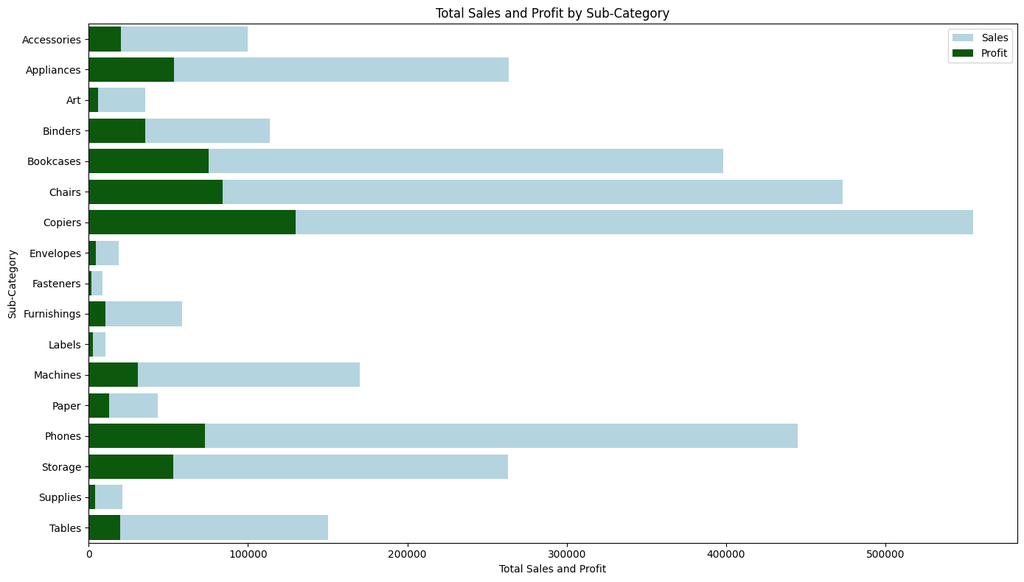

```python
grouped_data = df.groupby('Sub-Category')[['Sales', 'Profit']].sum().reset_index()

plt.figure(figsize=(14, 8), facecolor='white')
sns.barplot(x='Sales', y='Sub-Category', data=grouped_data, color='lightblue', label='Sales')
sns.barplot(x='Profit', y='Sub-Category', data=grouped_data, color='darkgreen', label='Profit')
plt.title('Total Sales and Profit by Sub-Category')
plt.legend()
plt.xlabel('Total Sales and Profit')
plt.ylabel('Sub-Category')
plt.tight_layout()
plt.show()
```

**Findings**:

The visual comparison shows the total sales and profit for each subcategory. Some subcategories have higher sales but lower profits, while others have lower sales but higher profits.

**Chart Type Selection**:

**Pre-attentive Attributes Used:**

Color: Different colors are used to distinguish between the two variables.

Length: The length of the bars represents the total sales and profit, making it easy to compare the values.

**Gestalt Principles Used:**

Proximity: The bars for sales and profit for each subcategory are placed close to each other, indicating they are related.

Similarity: The use of the same type of bars for sales and profit in each subcategory helps in grouping and comparing the values effectively.

### Question 2

#### Determine which State in the Central Region has the highest distribution of profits using box plot. Write the python code in the below cell to create the appropriate visual(single visual) to perform the above task .

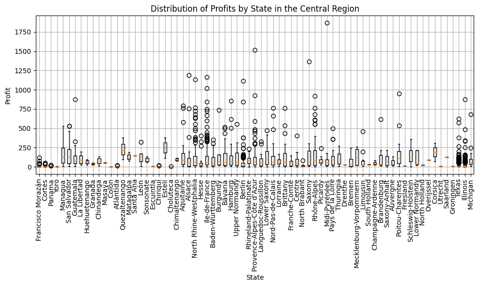

```
Total products sold: 36185
```

```python
central_region_df = df[df['Region'] == 'Central']


plt.figure(figsize=(10, 6), facecolor='white')
plt.title('Distribution of Profits by State in the Central Region')
plt.boxplot([central_region_df[central_region_df['State'] == state]['Profit'] for state in central_region_df['State'].unique()], labels=central_region_df['State'].unique())
plt.xticks(rotation=90)
plt.ylabel('Profit')
plt.xlabel('State')
plt.grid(True)
plt.tight_layout()
plt.show()

total_products_sold = df['Quantity'].sum()
print('Total products sold:', total_products_sold)
```

**Findings:**

**Chart Type Selection:** A box plot was chosen as it effectively displays the distribution of profits across different states in the Central Region, allowing for easy comparison of the profit ranges and identification of outliers.

**Pre-attentive Attributes:**

Position: The position of the box relative to the axis indicate the median and the central tendency of the data. Additionally, the position of outliers or extreme values are easily perceived.

Length: The length of the box plot whiskers and the position of the median line provide quick insights into the spread and central tendency of profits in each state.

**Gestalt Principles:**

Proximity: The box plot elements (whiskers, box, median line) are close to each other, indicating their relationship within each state's profit distribution.

Similarity: States with similar profit distributions tend to have similar box plot shapes, facilitating comparison based on visual similarity.

**Total Products Sold:**

The total number of products sold at the store is 36,185.

### Question 3

#### Identify which region has more number of orders and in which subcategory. Write the python code in the below cell to create appropriate(single)visual to perform the above task.

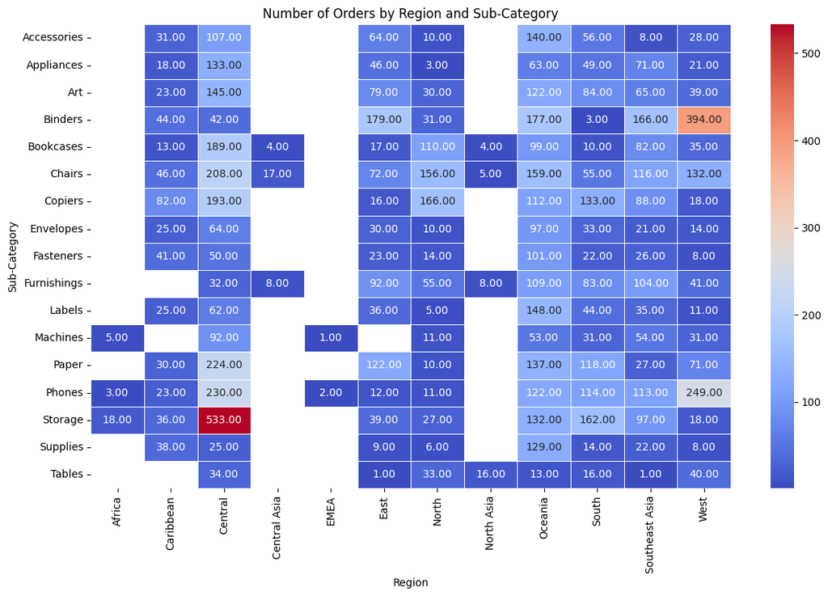

```python
orders_by_region_subcat = df.groupby(['Region', 'Sub-Category'])['Order ID'].count().reset_index()
pivot_data = orders_by_region_subcat.pivot('Sub-Category', 'Region', 'Order ID')


plt.figure(figsize=(12, 8), facecolor='white')
sns.heatmap(pivot_data, annot=True, fmt='.2f', cmap='coolwarm', linewidths=.5)
plt.title('Number of Orders by Region and Sub-Category')
plt.ylabel('Sub-Category')
plt.xlabel('Region')
plt.tight_layout()
plt.show()
```

**Findings:**

**Chart Type Selection**:

A heatmap was chosen for its ability to visually represent data in a matrix format, where colors correspond to the number of orders. This makes it easy to compare the number of orders across different regions and subcategories at a glance.

**Pre-attentive Attributes**:

Annotations: The numerical annotations within each cell provide precise information on the number of orders, aiding in quick comparison.

**Gestalt Principles**:

Similarity: Cells with similar color intensities group together visually, making it easier to identify regions and subcategories with similar order volumes.

Proximity: The arrangement of subcategories and regions next to each other allows for easy comparison across different categories and geographical areas.

Figure-Ground : Clear distinctions between the subcategory data and its background enhances readability. By establishing a clear figure-ground relationship, you can focus on the relevant information without distractions and can also see unavailable information at glance.

This heatmap effectively highlights the distribution of orders across different regions and subcategories, pinpointing areas of high activity and potential focus for business strategies.

### Question 4

#### In which region do all Product Categories fall beneath the overall average profit? Write the python code in the below cell to create the appropriate visual(single visual) to perform the above task .

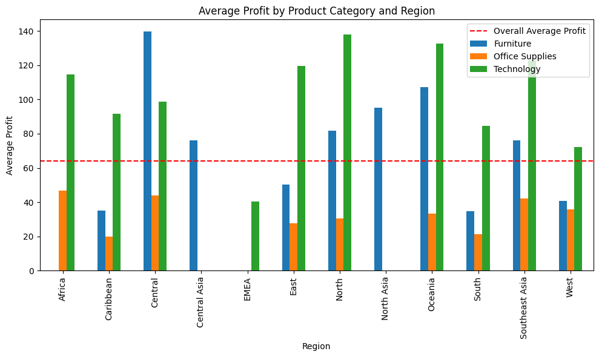

```python
overall_avg_profit = df['Profit'].mean()


avg_profit_by_region_category = df.groupby(['Region', 'Category'])['Profit'].mean().unstack()


regions_below_avg = avg_profit_by_region_category.apply(lambda x: all(x < overall_avg_profit), axis=1)
regions_below_avg = regions_below_avg[regions_below_avg].index.tolist()


plt.figure(figsize=(10, 6), facecolor='white')
avg_profit_by_region_category.plot(kind='bar', figsize=(10, 6))
plt.axhline(overall_avg_profit, color='red', linestyle='--', label='Overall Average Profit')
plt.title('Average Profit by Product Category and Region')
plt.ylabel('Average Profit')
plt.xlabel('Region')
plt.legend()
plt.tight_layout()
plt.show()
```

**Chart Type Selection:**

A bar chart was selected for its effectiveness in comparing the average profit of different product categories across various regions. It allows for an easy visual comparison of each category within a region against the overall average profit (indicated by the red dashed line). This type of visualization is intuitive and facilitates the identification of regions and categories that are underperforming or outperforming in terms of profit.

**Pre-attentive attributes used:**

Color: Color is used to differentiate between different product categories in the bar chart. Each category is represented by a different color, making it easy to visually distinguish between them.

Length: The length of the bars represents the average profit for each product category in the different regions. Longer bars indicate higher average profits, allowing for a quick comparison between categories.

**Gestalt principles used:**

Similarity: The use of color to represent different product categories follows the principle of similarity. Categories with the same color are perceived as belonging together, aiding in the visual grouping of related data points.

Proximity: The placement of the bars for each region close to each other adheres to the principle of proximity. Bars that are close together are perceived as related, helping viewers associate the average profits of different categories within the same region.

### Question 5

#### Find the customer with the lowest overall profit. What is his/her profit ratio? Write the python code in the below cell to create the appropriate visual(single visual) to perform the above task .

[figure not shown]

```
Customer with the lowest overall profit: LW-6825
Lowest overall profit: 0.642
Profit ratio for the customer with the lowest profit: 1.0398307428433336e-06
```

```python
total_profit_per_customer = df.groupby('Customer ID')['Profit'].sum()
top_10_customers_lowest_profit = total_profit_per_customer.nsmallest(10)
top_10_customers_lowest_profit = top_10_customers_lowest_profit.sort_values()
total_profit = total_profit_per_customer.sum()
profit_ratios = top_10_customers_lowest_profit / total_profit

plt.figure(figsize=(12, 8))
top_10_customers_lowest_profit[:-1].plot(kind='barh', color='skyblue', alpha=0.7)
plt.title('Top 10 Customers with Lowest Overall Profit')
plt.xlabel('Total Profit')
plt.ylabel('Customer ID')

customer_with_lowest_profit = top_10_customers_lowest_profit.idxmin()
lowest_profit = top_10_customers_lowest_profit.min()

plt.tight_layout()
plt.show()

print("Customer with the lowest overall profit:", customer_with_lowest_profit)
print("Lowest overall profit:", lowest_profit)
print("Profit ratio for the customer with the lowest profit:", profit_ratios[customer_with_lowest_profit])
```

**Chart Type Selection:** The bar chart was chosen because it effectively represents the total profit of each customer in a clear and concise manner. The horizontal orientation allows for easy comparison between customers and accommodates longer customer IDs.

**Pre-attentive Attributes Used:**

Length: The length of each bar represents the total profit of the corresponding customer, facilitating quick comparison.

Position: The position of each bar along the y-axis allows viewers to easily rank customers from top to bottom based on their total profit.

**Gestalt Principles Used:**

Proximity: The close proximity of bars emphasizes the relationship between different customers, making it easier to compare their profits.

Enclosure: The grouping of bars within the chart frame creates a visual enclosure, indicating that they belong together as part of the same dataset.

Continuity: Human eyes tries to find out things align with each other. We have sorted the data and it follows continuity.

# Group's choice-2 Marks

#### Frame 1 (more) question which will help in the EDA(Exploratory Data Analysis) of the given data set and answer the same using the best visual.

1. Write the question in a markdown cell
2. Below the question, in a coding cell, write the python code to create the visual to answer the question

#### Answer in markdown cells below the visual 1.Summarise your findings from the visual. 2.The reason for selecting the chart type you did. 3.Mention the pre-attentive attributes used.(atleast 2) 4.Mention the gestalt principles used.(atleast 2)

What is the average profit ratio across different product categories?

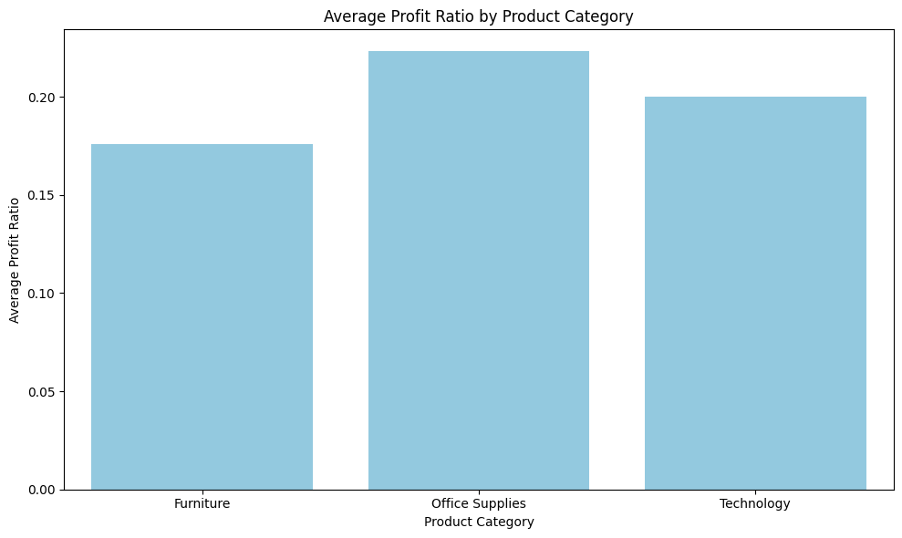

```python
df_grouped_category = df.groupby('Category').agg({'Profit':'sum', 'Sales':'sum'})
df_grouped_category['Average Profit Ratio'] = df_grouped_category['Profit'] / df_grouped_category['Sales']

plt.figure(figsize=(10, 6), facecolor='white')
sns.barplot(x=df_grouped_category.index, y=df_grouped_category['Average Profit Ratio'],color='skyblue')
plt.title('Average Profit Ratio by Product Category')
plt.ylabel('Average Profit Ratio')
plt.xlabel('Product Category')
plt.tight_layout()
plt.show()
```

**Findings:**

The visual likely shows the average profit ratio for each product category. Categories with higher bars indicate a higher average profit ratio, suggesting they are more profitable relative to their sales. Conversely, categories with lower bars suggest lower profitability. This analysis helps identify which categories are more efficient in generating profit from sales.

**Chart Type Selection:**

A bar plot is an excellent choice for comparing numerical values across different categories. It visually represents the average profit ratio of each product category, making it easy to compare them at a glance. The bar plot's simplicity and effectiveness in showing differences in magnitude make it ideal for this analysis.

**Pre-attentive Attributes Used:**

Length: The length of the bars directly correlates with the average profit ratio, allowing for quick comparison between categories.

**Gestalt Principles Used:**

Proximity: Bars placed closely together in the plot indicate they are part of the same category of data (average profit ratio), facilitating comparison.

Similarity: The use of similar shapes (bars) for representing data points across different categories emphasizes that the data being compared is of the same type (profit ratios).